# Recommendation_systems_Project

```python
import pandas as pd
import numpy as np
import matplotlib.pyplot as plt
import seaborn as sb
import scipy
from sklearn.model_selection import train_test_split
from scipy.sparse.linalg import svds
from surprise.model_selection import train_test_split as surp_trains_test
from surprise import KNNWithMeans, SVD
from surprise import Dataset
from surprise import accuracy
from surprise import Reader
```

```python
dataSet = pd.read_csv("ratings_Electronics.csv")
```

```python
dataSet.head(10)
```

|  | AKM1MP6P0OYPR | 0132793040 | 5.0 | 1365811200 |
| --- | --- | --- | --- | --- |
| 0 | A2CX7LUOHB2NDG | 0321732944 | 5.0 | 1341100800 |
| 1 | A2NWSAGRHCP8N5 | 0439886341 | 1.0 | 1367193600 |
| 2 | A2WNBOD3WNDNKT | 0439886341 | 3.0 | 1374451200 |
| 3 | A1GI0U4ZRJA8WN | 0439886341 | 1.0 | 1334707200 |
| 4 | A1QGNMC6O1VW39 | 0511189877 | 5.0 | 1397433600 |
| 5 | A3J3BRHTDRFJ2G | 0511189877 | 2.0 | 1397433600 |
| 6 | A2TY0BTJOTENPG | 0511189877 | 5.0 | 1395878400 |
| 7 | A34ATBPOK6HCHY | 0511189877 | 5.0 | 1395532800 |
| 8 | A89DO69P0XZ27 | 0511189877 | 5.0 | 1395446400 |
| 9 | AZYNQZ94U6VDB | 0511189877 | 5.0 | 1401321600 |

From the above dataset is seems clear that the columns are not labelled. Hence, following labels to the colums will be given:

Col 1 = userID Col 2 = productID Col 3 = ratings Col 4 = timeStamp

```python
 dataSet.columns = ['userID', 'productID', 'rating', 'timeStamp']
```

```python
dataSet.head(10)
```

|  | userID | productID | rating | timeStamp |
| --- | --- | --- | --- | --- |
| 0 | A2CX7LUOHB2NDG | 0321732944 | 5.0 | 1341100800 |
| 1 | A2NWSAGRHCP8N5 | 0439886341 | 1.0 | 1367193600 |
| 2 | A2WNBOD3WNDNKT | 0439886341 | 3.0 | 1374451200 |
| 3 | A1GI0U4ZRJA8WN | 0439886341 | 1.0 | 1334707200 |
| 4 | A1QGNMC6O1VW39 | 0511189877 | 5.0 | 1397433600 |
| 5 | A3J3BRHTDRFJ2G | 0511189877 | 2.0 | 1397433600 |
| 6 | A2TY0BTJOTENPG | 0511189877 | 5.0 | 1395878400 |
| 7 | A34ATBPOK6HCHY | 0511189877 | 5.0 | 1395532800 |
| 8 | A89DO69P0XZ27 | 0511189877 | 5.0 | 1395446400 |
| 9 | AZYNQZ94U6VDB | 0511189877 | 5.0 | 1401321600 |

```python
dataSet.isnull().sum()
```

```
userID       0
productID    0
rating       0
timeStamp    0
dtype: int64
```

There are no null values in the dataSet. Hence no need to handle the same.

```python
dataSet.info()
```

```
<class 'pandas.core.frame.DataFrame'>
RangeIndex: 7824481 entries, 0 to 7824480
Data columns (total 4 columns):
userID       object
productID    object
rating       float64
timeStamp    int64
dtypes: float64(1), int64(1), object(2)
memory usage: 238.8+ MB
```

```python
dataSet['rating'].mode()
```

```
0    5.0
dtype: float64
```

```python
dataSet.describe()
```

|  | rating | timeStamp |
| --- | --- | --- |
| count | 7.824481e+06 | 7.824481e+06 |
| mean | 4.012337e+00 | 1.338178e+09 |
| std | 1.380910e+00 | 6.900426e+07 |
| min | 1.000000e+00 | 9.127296e+08 |
| 25% | 3.000000e+00 | 1.315354e+09 |
| 50% | 5.000000e+00 | 1.361059e+09 |
| 75% | 5.000000e+00 | 1.386115e+09 |
| max | 5.000000e+00 | 1.406074e+09 |

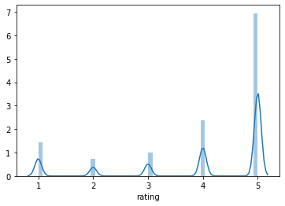

```python
sb.distplot(dataSet['rating'])
```

From the above description of the dataSet we can safely discard the timestamp column for this recommendation system. Hence the only column of our interest of which the description can be evaluated is the rating column. Thus, following data can be extracted from the rating column description:

1. The rating scale - 1 to 5
2. No one has rated a 0. Hence, likelihood of a missing value as '0' is less.
3. Mean or average rating is 4.01 that is 4.
4. Also, the most rated rating is 5 hence, the rating data is likely to be skewed negatively.

Also, the time stamp isn't relevant for this task, hence dropping the timestamp column.

```python
dataSet.drop(['timeStamp'], axis = 1, inplace=True)
```

Now finding the unique values as per the user ID and grouping the data on the basis of user ID. Also, organizing the data such that users those who have rated the most movies will be sorted and the data set will become less denser that will be easy to process further:

```python
users = dataSet['userID'].unique()
print("Total unique user count is = ", len(users))
users
```

```
Total unique user count is =  4201696
```

```
array(['A2CX7LUOHB2NDG', 'A2NWSAGRHCP8N5', 'A2WNBOD3WNDNKT', ...,
       'A180UGKKYCPDH0', 'A2IGIIABRZ5LAB', 'A10M2KEFPEQDHN'], dtype=object)
```

```python
data_grouped=dataSet.groupby('userID').size()
type(data_grouped)
```

```
pandas.core.series.Series
```

```python
products = dataSet['productID'].unique()
print("Total unique product count is = ", len(products))
```

```
Total unique product count is =  476001
```

```python
users_dat = dataSet['userID']
users_dat.shape
```

```
(7824481,)
```

```python
least_rating_users = data_grouped.index[data_grouped <= 25 ]
```

```python
least_rating_users
```

```
Index(['A00000262KYZUE4J55XGL', 'A000063614T1OE0BUSKUT',
       'A00009182QVLSWIGHLS1B', 'A00009661LC9LQPGKJ24G',
       'A00010809P09NUU6ZP6H', 'A00014061C2IZNE0YEILY',
       'A000145014WOTZJ5NSKOR', 'A00015222LZ55IJSVL5IX',
       'A00015228CUPGPF957DS', 'A0001528BGUBOEVR6T5U',
       ...
       'AZZZDSAJ757Z4', 'AZZZEWADNFNUM', 'AZZZJXM9GW3C5', 'AZZZM2FO19RUO',
       'AZZZMSZI9LKE6', 'AZZZOVIBXHGDR', 'AZZZRS1YZ8HVP', 'AZZZSIK7NFFVP',
       'AZZZWXXUPZ1F3', 'AZZZY1W55XHZR'],
      dtype='object', name='userID', length=4194373)
```

```python
dataSet.set_index('userID', inplace= True)
```

```python
dataSet.head(10)
```

| userID | productID | rating |
| --- | --- | --- |
| A2CX7LUOHB2NDG | 0321732944 | 5.0 |
| A2NWSAGRHCP8N5 | 0439886341 | 1.0 |
| A2WNBOD3WNDNKT | 0439886341 | 3.0 |
| A1GI0U4ZRJA8WN | 0439886341 | 1.0 |
| A1QGNMC6O1VW39 | 0511189877 | 5.0 |
| A3J3BRHTDRFJ2G | 0511189877 | 2.0 |
| A2TY0BTJOTENPG | 0511189877 | 5.0 |
| A34ATBPOK6HCHY | 0511189877 | 5.0 |
| A89DO69P0XZ27 | 0511189877 | 5.0 |
| AZYNQZ94U6VDB | 0511189877 | 5.0 |

```python
dataSet.drop(least_rating_users, axis = 0, inplace=True)
```

Now, the dataSet has only those records of the users who have rated >25 times. Thus we can see that the least rated in this dataSet is 26.

**Splitting the dataSet into training and testing data**

```python
dataSet.reset_index(level=0, inplace=True)
```

```python
train_dat,test_dat = train_test_split(dataSet,test_size = 0.3, random_state = 1)
```

**From the above train_dat, building a popularity based model**

Thus, let us find the most popular product that is the product which is rated the most. The top 5 such popular product could be recommended to the users who are new. Here, we'll take the mean of ratings each product has received and the top 5 mean will be displayed.

```python
train_dat.groupby('productID')['rating'].mean().sort_values(ascending= False).head()
```

```
productID
B005G9VGOY    5.0
B005J2JJ4C    5.0
B005J0200Y    5.0
B001925UZS    5.0
B005J0IDK0    5.0
Name: rating, dtype: float64
```

Thus we get a large spectrum of product IDs which are rated as 5. However, true popularity will be those where the count of such 5 ratings is high and those with highest count of 5 can be termed as popular products among the given users. Thus finding the same:

```python
train_dat.groupby('productID')['rating'].count().sort_values(ascending= False).head()
```

```
productID
B007WTAJTO    406
B003ES5ZUU    348
B0088CJT4U    279
B002WE6D44    246
B002V88HFE    241
Name: rating, dtype: int64
```

```python
rating_mean = pd.DataFrame(train_dat.groupby('productID')['rating'].mean())
rating_mean ['rating_counts'] = pd.DataFrame(train_dat.groupby('productID')['rating'].count())
```

```python
rating_mean.sort_values('rating_counts',ascending = False).head(5)
```

| productID | rating | rating_counts |
| --- | --- | --- |
| B007WTAJTO | 4.652709 | 406 |
| B003ES5ZUU | 4.862069 | 348 |
| B0088CJT4U | 4.179211 | 279 |
| B002WE6D44 | 4.703252 | 246 |
| B002V88HFE | 4.742739 | 241 |

Creating a dataFrame which has all the products with rating as complete 5 (as 5 is the highest rating any product has received here), with the number of times it is rated as 5. This is done to understand how popular the product actually is among all the users.

```python
rating_mean_5s = rating_mean[rating_mean['rating']==5]
```

```python
rating_mean_5s.sort_values(['rating_counts'], ascending = False).head(5)
```

| productID | rating | rating_counts |
| --- | --- | --- |
| B001196H3S | 5.0 | 21 |
| B00IVPU6AA | 5.0 | 19 |
| B001PS9UKW | 5.0 | 19 |
| B00006I53W | 5.0 | 19 |
| B00HG1L334 | 5.0 | 17 |

B007WTAJTO  
B003ES5ZUU  
B0088CJT4U  
B002WE6D44  
B002V88HFE

Validating the recommendation by checking what products the test_dat would recommend. Hence, performing the above steps to find out the dataFrame **rating_mean** of test_data

```python
rating_mean_test = pd.DataFrame(test_dat.groupby('productID')['rating'].mean())
rating_mean_test ['rating_counts'] = pd.DataFrame(test_dat.groupby('productID')['rating'].count())
rating_mean_test.sort_values('rating_counts',ascending = False).head(5)
```

| productID | rating | rating_counts |
| --- | --- | --- |
| B007WTAJTO | 4.683616 | 177 |
| B003ES5ZUU | 4.874214 | 159 |
| B002WE6D44 | 4.663551 | 107 |
| B0088CJT4U | 4.132075 | 106 |
| B009SYZ8OC | 4.560000 | 100 |

Thus, even in the test data the 4 out of top 5 products come out to be those recommended by the train_data.

**=======================================================================================================================** **=======================================================================================================================**

**Now building a collaborative recommendation system**

From the train_dat creating matrix where rows will be userID and the columns will be productID with rating as its content. This pivot matrix will be then used to create the SVD that is Singular Value Decomposition which will further be helpful to build the collborative recommender.

```python
train_dat.reset_index().head()
```

|  | index | userID | productID | rating |
| --- | --- | --- | --- | --- |
| 0 | 211145 | A1RVA6CTXUZJHT | B005HARR2W | 5.0 |
| 1 | 287887 | A2EMQB1VX2YFW6 | B00BQ4F9ZA | 5.0 |
| 2 | 13252 | A3N4VTNFPMTHEF | B00008VSL3 | 4.0 |
| 3 | 188033 | A3IY316DRNF5F2 | B004Q9T79Q | 1.0 |
| 4 | 99863 | A3TIU8KJ29GASQ | B001PKY2J4 | 3.0 |

```python
train_dat.info()
```

```
<class 'pandas.core.frame.DataFrame'>
Int64Index: 223155 entries, 211145 to 128037
Data columns (total 3 columns):
userID       223155 non-null object
productID    223155 non-null object
rating       223155 non-null float64
dtypes: float64(1), object(2)
memory usage: 6.8+ MB
```

```python
pivot_data = train_dat.pivot(index= 'userID', columns='productID', values='rating').fillna(0)
```

```python
pivot_data.head()
```

| productID userID | 0528881469 | 0594481813 | 0970407998 | 0972683275 | 1400501466 | 1400501520 | 1400501776 | 1400532620 | 1400532655 | 140053271X | ... | B00L8I6SFY | B00LA6T0LS | B00LAU0O9G | B00LBZ1Z7K | B00LED02VY | B00LGN7Y3G | B00LGQ6HL8 | B00LI4ZZO8 | B00LKG1MC8 | B00LPQRT34 |
| --- | --- | --- | --- | --- | --- | --- | --- | --- | --- | --- | --- | --- | --- | --- | --- | --- | --- | --- | --- | --- | --- |
| A100UD67AHFODS | 0.0 | 0.0 | 0.0 | 0.0 | 0.0 | 0.0 | 0.0 | 0.0 | 0.0 | 0.0 | ... | 0.0 | 0.0 | 0.0 | 0.0 | 0.0 | 0.0 | 0.0 | 0.0 | 0.0 | 0.0 |
| A100WO06OQR8BQ | 0.0 | 0.0 | 0.0 | 0.0 | 0.0 | 0.0 | 0.0 | 0.0 | 0.0 | 0.0 | ... | 0.0 | 0.0 | 0.0 | 0.0 | 0.0 | 0.0 | 0.0 | 0.0 | 0.0 | 0.0 |
| A101L4HF0IZ33C | 0.0 | 0.0 | 0.0 | 0.0 | 0.0 | 0.0 | 0.0 | 0.0 | 0.0 | 0.0 | ... | 0.0 | 0.0 | 0.0 | 0.0 | 0.0 | 0.0 | 0.0 | 0.0 | 0.0 | 0.0 |
| A101OAAMZYWQ3U | 0.0 | 0.0 | 0.0 | 0.0 | 0.0 | 0.0 | 0.0 | 0.0 | 0.0 | 0.0 | ... | 0.0 | 0.0 | 0.0 | 0.0 | 0.0 | 0.0 | 0.0 | 0.0 | 0.0 | 0.0 |
| A102RLOGIBBDMW | 0.0 | 0.0 | 0.0 | 0.0 | 0.0 | 0.0 | 0.0 | 0.0 | 4.0 | 0.0 | ... | 0.0 | 0.0 | 0.0 | 0.0 | 0.0 | 0.0 | 0.0 | 0.0 | 0.0 | 0.0 |

5 rows × 74977 columns

Now as per SVDs formula finding the U, Sigma and Vt. Later a dot product of (U and sigma) and Vt will be tabken to find the predicted values.

```python
U, sigma, Vt = svds(pivot_data, k = 25)
sigma = np.diag(sigma)
```

```python
pred_ratings_allUsers = np.dot(np.dot(U, sigma),Vt)
```

```python
pred_dataSet = pd.DataFrame(pred_ratings_allUsers, columns=pivot_data.columns)
```

```python
pred_dataSet.shape
```

```
(7323, 74977)
```

```python
pred_dataSet['userID'] = pivot_data.index
```

```python
pred_dataSet.set_index(['userID'], inplace = True)
```

The above data frame is the predictions of ratings that all the users will do. Thus, if a user has never purchased a particular product, his liking and rating is predicted for the same and other items based on his ratings will be recommended.

```python
#Following function will take userID as an input and recommend the n number products for it based on above dataFrame

def recommendProduct(userID,n_recommendations):
    #user_index = userID-1
    user_ratings = pivot_data.loc[userID].sort_values(ascending = False)
    user_Preds = pred_dataSet.loc[userID].sort_values(ascending = False)
    user_recom_table = pd.concat([user_ratings,user_Preds], axis = 1)
    user_recom_table.index.name = 'Recommended Products'
    user_recom_table.columns = ['Actual_ratings', 'Predicted_ratings']
    user_recom_table = user_recom_table.loc[user_recom_table.Actual_ratings == 0]
    user_recom_table = user_recom_table.sort_values('Predicted_ratings', ascending = False)
    print("Following are the "+ str(n_recommendations) + ' for the user ' + str(userID) + ' :')
    return user_recom_table.head(n_recommendations)
```

```python
user_data_temp =recommendProduct(userID='A3CW0ZLUO5X2B1' , n_recommendations=37256)
```

```
Following are the 37256 for the user A3CW0ZLUO5X2B1 :
```

Calculating the RMSE of the prediction model to gauge how reliable our recommnedations are.

```python
mean_pivot = pivot_data.mean()
mean_pred = pred_dataSet.mean()
```

```python
mean_pivot.head()
```

```
productID
0528881469    0.000273
0594481813    0.000410
0970407998    0.000546
0972683275    0.008466
1400501466    0.003277
dtype: float64
```

```python
mean_pred.head()
```

```
productID
0528881469    0.000037
0594481813    0.000014
0970407998    0.000840
0972683275    0.007547
1400501466    0.001666
dtype: float64
```

```python
rmse_data = pd.concat([mean_pivot,mean_pred],axis = 1)
rmse_data.columns = ['avg_ratings','avg_preds']
```

```python
RMSE = round((((rmse_data.avg_ratings - rmse_data.avg_preds) ** 2).mean() ** 0.5), 5)
```

```python
RMSE
```

```
0.00103
```

**=======================================================================================================================** **Now trying the same collaborative recommendation system with surprise library/ module**

```python
dataSet.head()
```

|  | userID | productID | rating |
| --- | --- | --- | --- |
| 0 | A1H8PY3QHMQQA0 | 0528881469 | 2.0 |
| 1 | A3BY5KCNQZXV5U | 0594451647 | 5.0 |
| 2 | A2QBZA4S1ROX9Q | 0594481813 | 3.0 |
| 3 | AT09WGFUM934H | 0594481813 | 3.0 |
| 4 | A32HSNCNPRUMTR | 0970407998 | 1.0 |

```python
reader_var = Reader(rating_scale=(1,5))
```

```python
data_surp = Dataset.load_from_df(dataSet,reader=reader_var)
```

```python
surp_train_dat, surp_test_dat = surp_trains_test(data_surp, test_size=0.3)
```

```python
collab_recomm_algo = KNNWithMeans(k=15, sim_options={'name':'pearson_baseline', 'user_based':True})
```

```python
collab_recomm_algo.fit(surp_train_dat)
```

```
Estimating biases using als...
Computing the pearson_baseline similarity matrix...
Done computing similarity matrix.
```

```
<surprise.prediction_algorithms.knns.KNNWithMeans at 0x1bf2912f9e8>
```

```python
surp_preds = collab_recomm_algo.test(surp_test_dat)
```

```python
surp_preds
```

[output not shown]

[output cut: 946 more lines]

[output not shown]

```python
accuracy.rmse(surp_preds)
```

```
RMSE: 1.0993
```

```
1.0992980985095087
```

```python
surp_SVD = SVD()
```

```python
surp_SVD.fit(surp_train_dat)
```

```
<surprise.prediction_algorithms.matrix_factorization.SVD at 0x1bf338c1d30>
```

```python
svd_preds = surp_SVD.test(surp_test_dat)
```

```python
accuracy.rmse(svd_preds)
```

```
RMSE: 1.0359
```

```
1.0358844657727821
```

**========================================================================================================================** The top 5 recommendations by our systems are:

```python
#As per popularity based system:
rating_mean_test.sort_values('rating_counts',ascending = False).head(5)
```

| productID | rating | rating_counts |
| --- | --- | --- |
| B007WTAJTO | 4.683616 | 177 |
| B003ES5ZUU | 4.874214 | 159 |
| B002WE6D44 | 4.663551 | 107 |
| B0088CJT4U | 4.132075 | 106 |
| B009SYZ8OC | 4.560000 | 100 |

```python
#As per Collaborative system using svds: (for user A2EMQB1VX2YFW6)
recommendProduct(userID='A2EMQB1VX2YFW6', n_recommendations=5)
```

```
Following are the 5 for the user A2EMQB1VX2YFW6 :
```

| Recommended Products | Actual_ratings | Predicted_ratings |
| --- | --- | --- |
| B00DR0PDNE | 0.0 | 0.183989 |
| B005CT56F8 | 0.0 | 0.168166 |
| B00E3W15P0 | 0.0 | 0.147248 |
| B00007E7JU | 0.0 | 0.141843 |
| B001TH7GUU | 0.0 | 0.128115 |

**=======================================================================================================================**

Thus, from the above activity of building the popularity and collaborative based recommendation system, we can conclude and summarise the following:

1. Popularity based system is generalized and non personal. It will recommend the top N and popular product/ items in the database. No user preferences are taken into consideration.

   1.a. Data sparsity or density won't have much affect on these systems.
1. Collaborative filtering/ recommenders are user based systems that consider the user preferences by guaging the user's previous ratings and behaviour. The matrix based evaluation helps to predict the rating this user may give to a certain item, to which the user has never rated and on this basis, top N can be recommended to the user.

   2.a. Data density affects the recommendation. More sparse the data - vertically or horizantally will affect. If there are too many products and users, which are sparsely rated, such data will be not effective to predict ratings. For example for a single user, if we try to predict the ratings for Nth item out of a few 10 thousands of products, provided the user has only rated a handful of products.

   2.b Collaborative filtering is helpful in cases where many users have equally rated throughout the oriduct spectrum.
1. Hybrid recommendations are more efficient where collaborative and content based systems can help to achieve a near actual prediction and recommendation in cases of sparse data.